# 5. ggplot2 (Bar Chart)

Masahiko Asano

2026-07-23

- **`R packages` used in this section**

```r
library(DT)
library(gapminder)
library(gghighlight)
library(ggrepel)
library(stargazer)
library(tidyverse)
```

# 1. What is bar chart?

- A histogram and a bar chart look very similar
- A bar chart visualizes a discrete variable
- A histogram visualizes a continuous variable
- A bar chart has lines between bars
- A histogram does not have lines between bars

| Variables | Graph | Feature |
| --- | --- | --- |
| Discrete | **Bar chart** | Lines between bars |
| Continuous | **Histogram** | No Lines between bars |

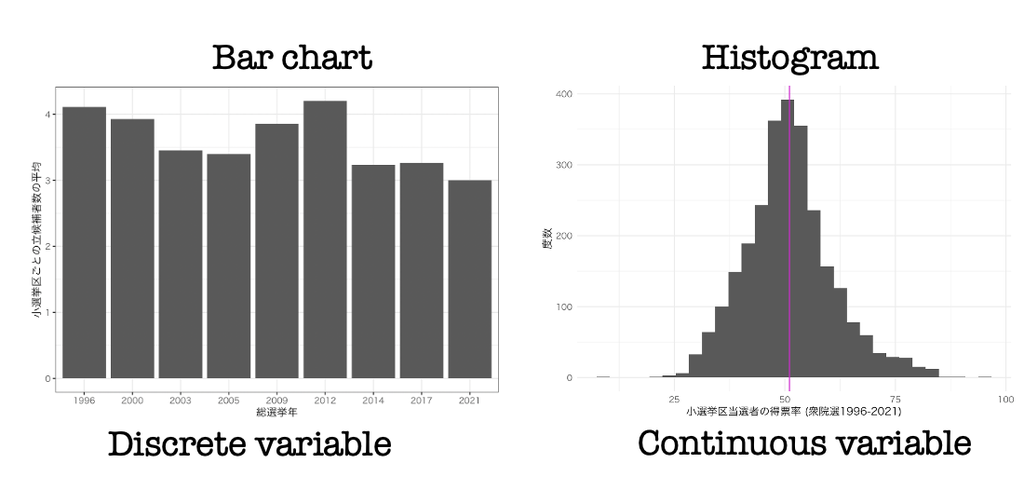

##### Histogram:

- `x-axis`: Vote share (%) in lower house election in Japan (1996-2021)
- `y-axis`: The number of candidates
- Vote share ranged from 0% to 100%, and there are a number of values, such as 0.1%, 0.01%,….
- You need to set up bars without lines between them  
  → Histogram does not have bars  
  → But, each bar contains the following two information:
1. location in `x-axis`
2. height in `y-axis`

# 2. Data preparation

The lower house election data in Japan: 1996-2021 (`hr96-26.csv`)  
・click hr96-26.csv and download to your computer  
・Read the election data and name it as `df`

```r
df <- read_csv("data/hr96-26.csv",
na = ".")
```

## Check whether you safely read the data

```r
names(df)
```

```
 [1] "year"          "pref"          "ku"            "kun"
 [5] "rank"          "wl"            "nocand"        "seito"
 [9] "j_name"        "name"          "previous"      "gender"
[13] "age"           "exp"           "status"        "vote"
[17] "voteshare"     "eligible"      "turnout"       "seshu_dummy"
[21] "jiban_seshu"   "nojiban_seshu"
```

[output not shown]

- Check the class of variables included in `df`

```r
str(df)
```

```
spc_tbl_ [11,892 × 22] (S3: spec_tbl_df/tbl_df/tbl/data.frame)
 $ year         : num [1:11892] 1996 1996 1996 1996 1996 ...
 $ pref         : chr [1:11892] "愛知" "愛知" "愛知" "愛知" ...
 $ ku           : chr [1:11892] "aichi" "aichi" "aichi" "aichi" ...
 $ kun          : num [1:11892] 1 1 1 1 1 1 1 2 2 2 ...
 $ rank         : num [1:11892] 7 6 5 4 3 2 1 8 7 6 ...
 $ wl           : num [1:11892] 0 0 0 0 0 0 1 0 0 0 ...
 $ nocand       : num [1:11892] 7 7 7 7 7 7 7 8 8 8 ...
 $ seito        : chr [1:11892] "無所" "国民党" "文化フォーラム" "共産" ...
 $ j_name       : chr [1:11892] "浅野光雪" "山田浩" "伊東マサコ" "岩中美保子" ...
 $ name         : chr [1:11892] "ASANO, KOSETSU" "YAMADA, HIROSHI" "ITO, MASAKO" "IWANAKA, MIHOKO" ...
 $ previous     : num [1:11892] 0 0 0 0 1 3 1 0 0 0 ...
 $ gender       : chr [1:11892] "male" "male" "female" "female" ...
 $ age          : num [1:11892] 45 51 51 43 53 72 47 43 47 61 ...
 $ exp          : num [1:11892] NA NA NA 2177203 9231284 ...
 $ status       : num [1:11892] 0 0 0 0 1 2 1 0 0 0 ...
 $ vote         : num [1:11892] 312 566 616 22209 33503 ...
 $ voteshare    : num [1:11892] 0.2 0.3 0.4 13.3 20.1 25.7 40 0.2 0.2 0.4 ...
 $ eligible     : num [1:11892] 346774 346774 346774 346774 346774 ...
 $ turnout      : num [1:11892] 49.2 49.2 49.2 49.2 49.2 49.2 49.2 51.8 51.8 51.8 ...
 $ seshu_dummy  : num [1:11892] 0 0 0 0 0 0 0 0 0 0 ...
 $ jiban_seshu  : chr [1:11892] NA NA NA NA ...
 $ nojiban_seshu: chr [1:11892] NA NA NA NA ...
 - attr(*, "spec")=
  .. cols(
  ..   year = col_double(),
  ..   pref = col_character(),
  ..   ku = col_character(),
  ..   kun = col_double(),
  ..   rank = col_double(),
  ..   wl = col_double(),
  ..   nocand = col_double(),
  ..   seito = col_character(),
  ..   j_name = col_character(),
  ..   name = col_character(),
  ..   previous = col_double(),
  ..   gender = col_character(),
  ..   age = col_double(),
  ..   exp = col_double(),
  ..   status = col_double(),
  ..   vote = col_double(),
  ..   voteshare = col_double(),
  ..   eligible = col_double(),
  ..   turnout = col_double(),
  ..   seshu_dummy = col_double(),
  ..   jiban_seshu = col_character(),
  ..   nojiban_seshu = col_character()
  .. )
 - attr(*, "problems")=<externalptr>
```

- **`chr` means character and `num` means numeric**  
  → No problem

### Descriptive statistics: `df`

```r
library(stargazer)
```

- Type `{r, results = "asis"}` as chunk option

```r
stargazer(as.data.frame(df),
type ="html",
digits = 2)
```

| Statistic | N | Mean | St. Dev. | Min | Max |
| --- | --- | --- | --- | --- | --- |
| year | 11,892 | 2,011.09 | 9.63 | 1,996 | 2,026 |
| kun | 11,892 | 5.90 | 5.33 | 1 | 30 |
| rank | 11,892 | 2.48 | 1.28 | 1 | 9 |
| wl | 11,892 | 0.48 | 0.67 | 0 | 2 |
| nocand | 11,892 | 3.96 | 1.12 | 2 | 9 |
| previous | 11,892 | 1.52 | 2.54 | 0 | 19 |
| age | 11,888 | 51.62 | 11.30 | 25 | 94 |
| exp | 9,479 | 7,125,574.00 | 5,201,119.00 | 535 | 27,462,362 |
| status | 11,892 | 0.49 | 0.62 | 0 | 2 |
| vote | 11,892 | 54,787.54 | 39,815.58 | 177 | 210,515 |
| voteshare | 11,892 | 27.34 | 19.21 | 0.10 | 95.30 |
| eligible | 10,773 | 351,536.30 | 66,499.14 | 191,241 | 495,212 |
| turnout | 10,773 | 59.75 | 7.10 | 42.09 | 83.80 |
| seshu_dummy | 11,892 | 0.09 | 0.29 | 0 | 1 |

# 3. Draw a bar chart

## 3.1 Draw a simple bar chart (1)

| **Geometric object** | **What you can do** |
| --- | --- |
| **`ggplot()`** | **Prepare a canvas** |
| **`geom_bar()`** | **Draw a bar chart** |

- You need the following two data:
1. `year` (1996, 2000, 2003,…, 2026)
2. the number of candidates in each election
- You use the data frame, `df`
- Using `table()`, check the number of candidates in each election

```r
table(df$year)
```

```
1996 2000 2003 2005 2009 2012 2014 2017 2021 2024 2026
1261 1199 1026  989 1139 1294  959  936  857 1113 1119
```

- You have the two data necessary to draw a bar chart
- Assign `year` (`x-axis`), and the number of candidates (`y-axis`)
- `df` contains `year`, but `df` does not have the variable representing the number of candidates
- In drawing a bar chart, you need to map `x` in `geom_bar(aes())`
- You do not have to map `y` in `geom_bar(aes())`
- {`ggplot2`} automatically calculates and showsit in a bar chart  
  → You map as `geom_bar(aes(x = year))`
- If you add `labs()` layer, you can put a label on `x-axis` and `y-axis`

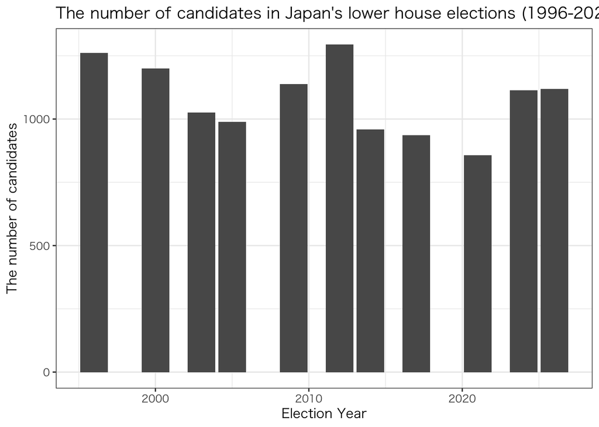

```r
df %>%
  ggplot() +
  geom_bar(aes(x = year)) +
  labs(x = "Election Year",
       y = "The number of candidates") +
  ggtitle("The number of candidates in Japan's lower house elections (1996-2021)") +
  theme_bw(base_family = "HiraKakuProN-W3")
```

- It does not look good with different size of intervals between bars
- This because the class of `year` is numeric
- Check the class of `year` by using `str()`

```r
str(df$year)
```

```
 num [1:11892] 1996 1996 1996 1996 1996 ...
```

- As expected, the calss of `year` if `numeric`  
  → `R` understands `year` as a continuous variable  
  → The lower house elections in Japan are held with different intervals within 4 years  
  → That is why, we have this ugly bar chart

**Solution**

- Change the `class` of `year` from `numeric` to `factor`

```r
df$year <- factor(df$year)
```

- Check the `class` of `year`

```r
str(df$year)
```

```
 Factor w/ 11 levels "1996","2000",..: 1 1 1 1 1 1 1 1 1 1 ...
```

- The `class` of `year` is changed to `factor`

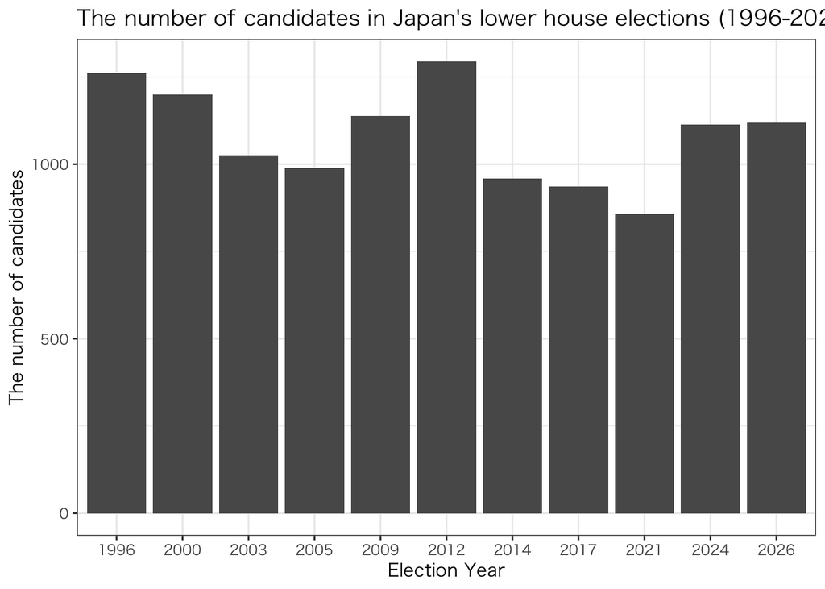

```r
df %>%
  ggplot() +
  geom_bar(aes(x = year)) +
  labs(x = "Election Year",
       y = "The number of candidates") +
  ggtitle("The number of candidates in Japan's lower house elections (1996-2021)") +
  theme_bw(base_family = "HiraKakuProN-W3")
```

- You can save this bar chart with an appropriate name on it, like `bar_plot1`  
- If this is the case, then you type as follows:

```r
bar_plot1 <- df %>%
  ggplot() +
  geom_bar(aes(x = year)) +
  labs(x = "Election Year",
       y = "The number of candidates") +
  ggtitle("The number of can didates in Japan's lower house elections (1996-2021)") +
  theme_bw(base_family = "HiraKakuProN-W3")
```

- See `5. How to save graphs` for how to save graphs
- If you want to output the graph, just type the object name, in this case, `bar_plot1` in a chunk and knit it

## 3.2 Draw a simple bar chart (2)

- Next, let’s drawa simple bar chart of the average number of candidates **in each single-member-district** in Japanese lower house election between 1996 and 2021
- You need the following two data:
1. `year` (1996, 2000, 2003,…, 2026)
2. the number of candidates in each electoral district and in each election
- You use the data frame, `df`
- Using `table()`, check the number of candidates in each election
- Assign `year` (`x-axis`), and the average number of candidates in each electoral district and in each election (`y-axis`)
- `df` contains `year`, but `df` does not have the variable representing the average number of candidates in each electoral district and in each election
- You can calculate this variable by using `group_by()` and save its results as `ave_nocand1`

```r
df1 <- df %>%
  group_by(year, ku) %>%
  summarise(ave_nocand1 = mean(nocand, na.rm = TRUE))

df1
```

```
# A tibble: 517 × 3
# Groups:   year [11]
   year  ku        ave_nocand1
   <fct> <chr>           <dbl>
 1 1996  aichi            6.33
 2 1996  akita            3.4
 3 1996  aomori           3.93
 4 1996  chiba            4.75
 5 1996  ehime            3.57
 6 1996  fukui            4.17
 7 1996  fukuoka          3.90
 8 1996  fukushima        3.67
 9 1996  gifu             3.78
10 1996  gunma            3.84
# ℹ 507 more rows
```

- What you need here is the average number of candidates in each district and in each election
- You calculate the average of `ave_nocand1` in each election and save it as `ave_nocand2`

```r
df1 <- df1 %>%
  group_by(year) %>%
  summarise(ave_nocand2 = mean(ave_nocand1, na.rm = TRUE))

df1
```

```
# A tibble: 11 × 2
   year  ave_nocand2
   <fct>       <dbl>
 1 1996         4.11
 2 2000         3.93
 3 2003         3.45
 4 2005         3.40
 5 2009         3.86
 6 2012         4.20
 7 2014         3.23
 8 2017         3.27
 9 2021         3.00
10 2024         3.75
11 2026         3.97
```

- You use an geometric object, `geom_bar()` and map `aes()` as follows:  
  ・`x-axis`: `x = year`  
  ・`y-axis`: `y = ave_nocand2`  
  → map `geom_bar(aes(x = year, y = ave_nocand2))`
- When you map both `x` and `y`, you need to assign as `stat = "identity"` inside of `geom_bar()` and out of `aes()`
- If you add `labs()` layer, you can put a label on `x-axis` and `y-axis`

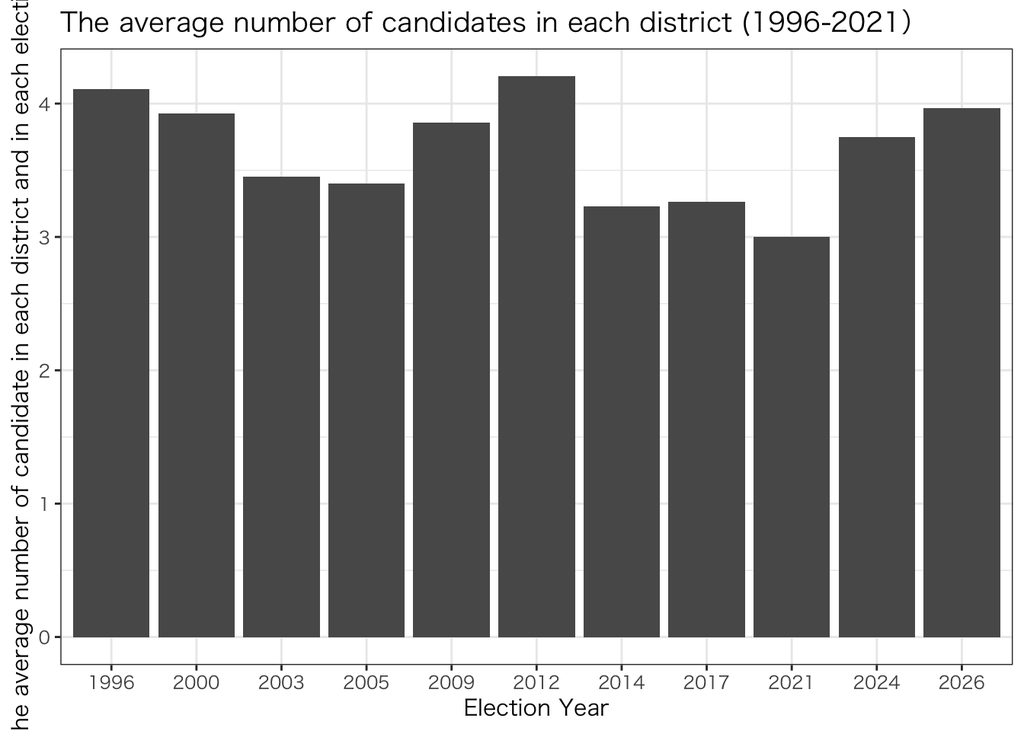

```r
df1 %>%
  ggplot() +
  geom_bar(aes(x = year,
               y = ave_nocand2),
           stat = "identity") +
  labs(x = "Election Year", y = "The average number of candidate in each district and in each election") +
  ggtitle("The average number of candidates in each district (1996-2021）") +
  theme_bw(base_family = "HiraKakuProN-W3")
```

## 3.3 Modify numeric values into characters

- Let’s draw a bar chart of the number of candidates by `status` (incumbent, challenger, and former-incumbent) in Japanese lower house elections (1996-2021)
- You need the following two data:
1. `status`: (challenger = 0, incumbent = 1, former-incumbent = 2)
2. `N` : The number of candidates by status
- You use the data frame, `df`
- Let’s check `status`, by using `table()`

```r
table(df$status)
```

```
   0    1    2
6808 4315  769
```

- You have all data you need to draw a bar chart
- `x-axis`: `status`
- `y-axis`: `N`
- `df` contains `status`, but `df` does not have `N`
- **In drawing a bar chart, you need to map `x` in `geom_bar(aes())`**
- You do not have to map `y` in `geom_bar(aes())`
- {`ggplot2`} automatically calculates and shows it in a bar chart  
  → You map as `geom_bar(aes(x = status))`
- If you add `labs()` layer, you can put a label on `x-axis` and `y-axis`

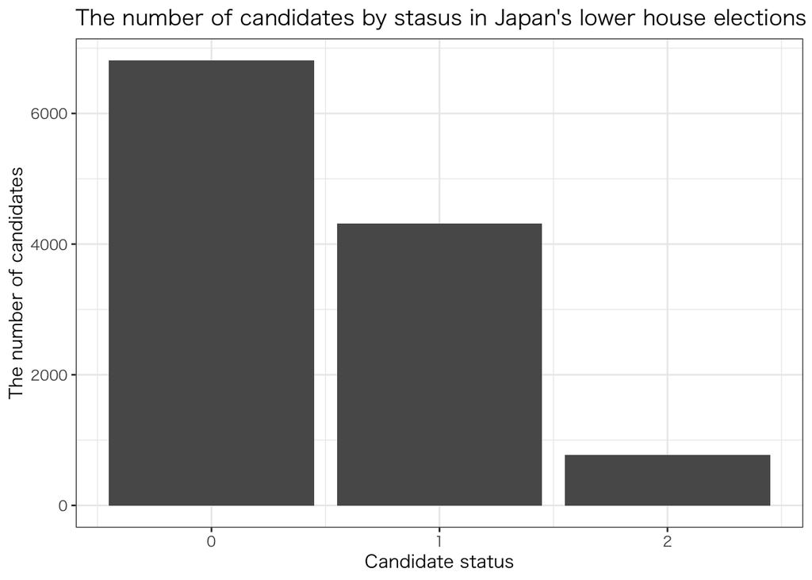

```r
df %>%
  ggplot() +
  geom_bar(aes(x = status)) +
  labs(x = "Candidate status",
       y = "The number of candidates") +
  ggtitle("The number of candidates by stasus in Japan's lower house elections (1996-2021)") +
  theme_bw(base_family = "HiraKakuProN-W3")
```

- `x-axis` shows 0, 1, and 2 showing candidate’s status
- You need to fix this to challengers, incumbents, and former-incumbents
- Using `case_when()`, you re-code `status`
- Add `status_J` as a new variable to `df` and override it as `df2`

```r
df2 <- df %>%
  mutate(status_J = case_when(status == "0" ~ "challengers",
 status == "1" ~ "incumbents",
 TRUE  ~ "former-incumbents"))
```

- Instead of typing `x = status`, you need to type `x = status_J` in mapping

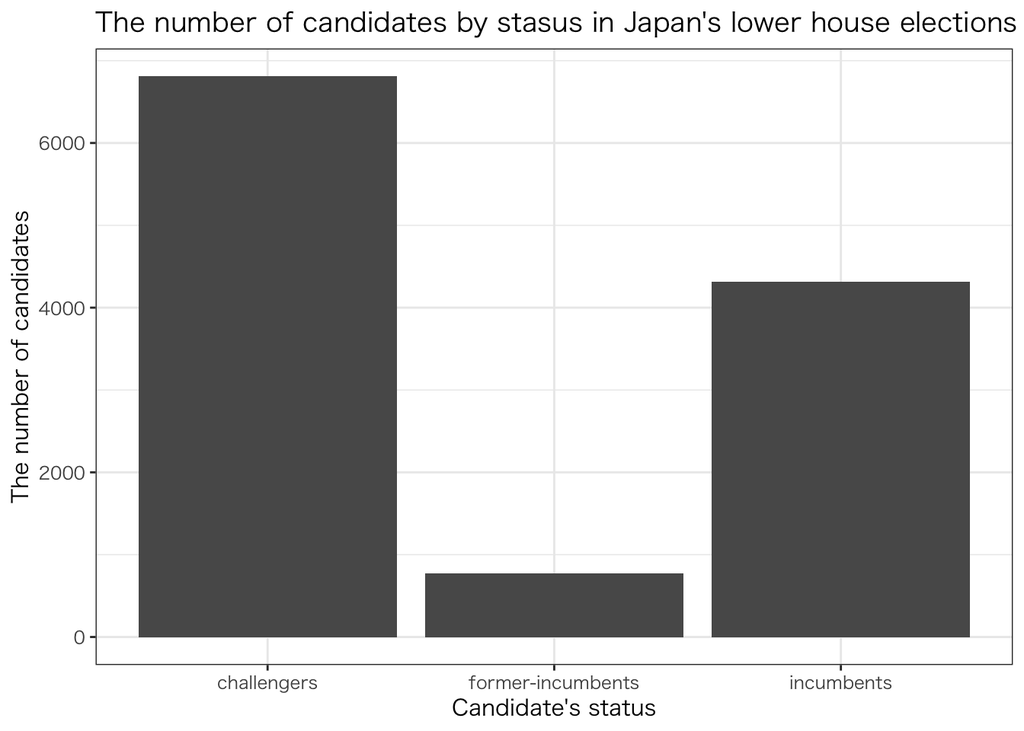

```r
df2 %>%
  ggplot() +
  geom_bar(aes(x = status_J)) +
  labs(x = "Candidate's status",
  y = "The number of candidates") +
  ggtitle("The number of candidates by stasus in Japan's lower house elections (1996-2021)") +
  theme_bw(base_family = "HiraKakuProN-W3")
```

How to fix the garbled characters in a graph  
**For Windows users**: Add the following R code  
`theme_bw(base_family = "HiraKakuProN-W3")`

**For Mac users**: Add the following R code  
`theme_bw(base_family = "HiraKakuProN-W3")`

## 3.4 How to change the order of bars

### 3.4.1 `factor()`

- The bar chart you made in the previous sub-section shows challengers, former-incumbents, and incumbents in order
- Suppose you want to change the order to incumbents, challengers, former-incumbents
- To do this, you need to **change the class of status_J to factor**
- In using `mutate()`, you change the class of `status_j` to factor and then pass it to `ggplot()` → Change the order by hand: `levels = c("incumbents", "challengers", "former-incumbents")`

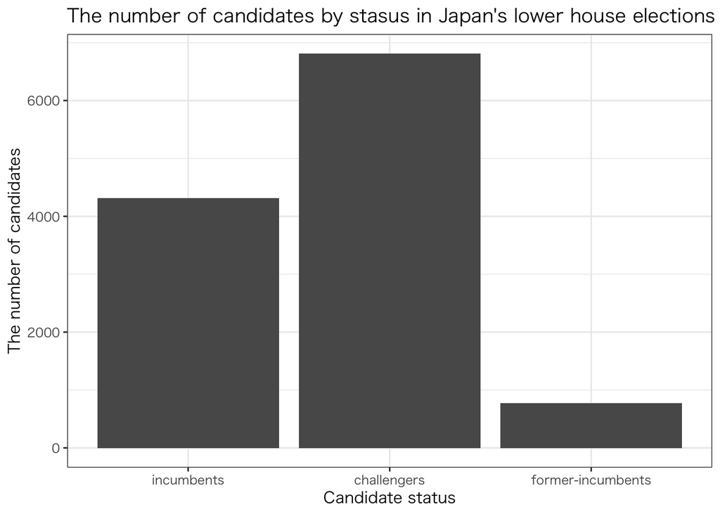

```r
df2 %>%
mutate(status_J = factor(status_J,
levels = c("incumbents", "challengers", "former-incumbents"))) %>%
ggplot() +
  geom_bar(aes(x = status_J)) +
  labs(x = "Candidate status",
       y = "The number of candidates") +
  ggtitle("The number of candidates by stasus in Japan's lower house elections (1996-2021)") +
  theme_bw(base_family = "HiraKakuProN-W3")
```

- Now, you get what you want!

### 3.4.2 `fct_inorder()`

- To use `fct_inorder()`, you need to install {`forcats`}
- {`tidyverse`} includes {`forcats`}
- If you install {`tidyverse`}, then you do not have to install {`forcats`}.
- `fct_inorder()` change the class of variables in the parenthesis to `factor` and put them in order
- Let’s check order of the value in `status_J`

```r
head(df2$status_J)
```

```
[1] "challengers"       "challengers"       "challengers"
[4] "challengers"       "incumbents"        "former-incumbents"
```

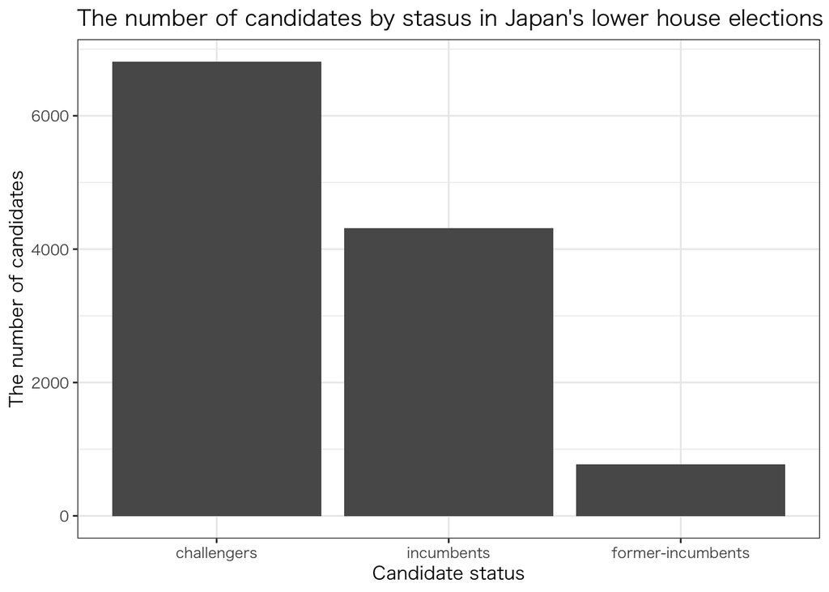

```r
df2 %>%
mutate(status_J = fct_inorder(status_J)) %>%
  ggplot() +
  geom_bar(aes(x = status_J)) +
  labs(x = "Candidate status", y = "The number of candidates") +
  ggtitle("The number of candidates by stasus in Japan's lower house elections (1996-2026)") +
  theme_bw(base_family = "HiraKakuProN-W3")
```

## 3.5 Add another dimention

### 3.5.1 The number of candidates by party in the 2021 HR election in Japan

- Usually, a bar chart has `x-axis` and `y-axis`
- A bar includes the information of a HR election (`x-axis`) and the number of candidates (`y-axis`)
- The number of dimentions means the amount of information
- This information is the number of arguments within `aes()`
- Let’s draw a bar chart of the number of candidates by party (`seito`) in the 2021 HR election

```r
df21 <- df %>%
  filter(year == 2021)
```

- Check the list of parties running for the 2021 HR election in Japan.

```r
unique(df21$seito)
```

```
 [1] "Ｎ党" "立憲" "自民" "国民" "維新" "共産" "れい" "無所" "諸派" "社民"
[11] "公明"
```

- The number of parties is 11
- Let’s change the class of `seito` to `factor` and assign the order of values of `seito` as you like

**How to assign the order of the values in `seito`**  
・For instance, suppose you want to arrange, 自民、立憲、共産 in order, you assign as follows:

`mutate(seito = factor(seito,`  
`levels = c("自民", "立憲", "共産")))`

```r
df21 <- df21 %>%
drop_na(seito) %>%
mutate(seito = factor(seito,
levels = c("自民",
 "立憲",
 "共産",
 "維新",
 "無所",
 "Ｎ党",
 "国民",
 "れい",
 "公明",
 "諸派",
 "社民")))
```

### 3.5.2 Calulate the number of candidates (`N`)

- Calculate the number of candidates (`N`) by gender and party  
  → Put the object name (`res_1`) on the outcome

```r
 res_1 <- df21 %>%
group_by(seito, gender, wl) %>%
summarise(N = n())
```

```r
DT::datatable(res_1)
```

|  | seito | gender | wl | N |
| --- | --- | --- | --- | --- |
| 1 | 自民 | female | 0 | 6 |
| 2 | 自民 | female | 1 | 14 |
| 3 | 自民 | female | 2 | 2 |
| 4 | 自民 | male | 0 | 28 |
| 5 | 自民 | male | 1 | 173 |
| 6 | 自民 | male | 2 | 54 |
| 7 | 立憲 | female | 0 | 24 |
| 8 | 立憲 | female | 1 | 9 |
| 9 | 立憲 | female | 2 | 4 |
| 10 | 立憲 | male | 0 | 94 |

[output cut: 31 more lines]

- Let’s visualize the results

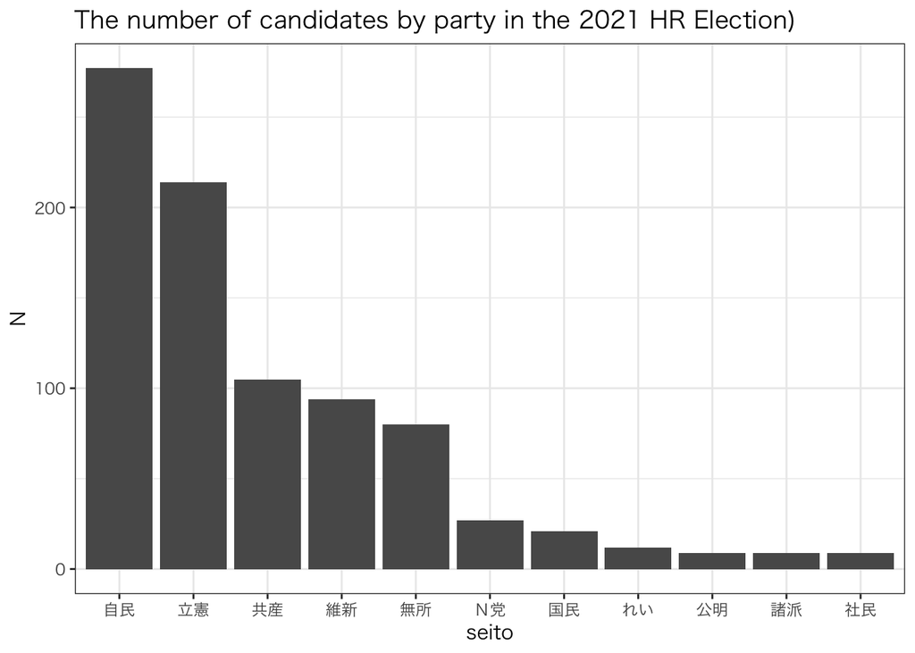

```r
res_1 %>%
  ggplot() +
  geom_bar(aes(x = seito,
               y = N),
           stat = "identity") +
  ggtitle("The number of candidates by party in the 2021 HR Election)") +
  theme_bw(base_family = "HiraKakuProN-W3")
```

- This bar chart has the following two information:
- `x-axis`: Party names `seito`
- `y-axis`: The number of candidates (`N`)

### 3.5.2 Add another dimension

##### `fill = gender`

- Let’s add another dimension (`gender`) to the bar chart above
- When you add another dimension, you add an argument within `aes()`
- You can customize surface with `fill`
- You can customize the color of the framer border with `color` - You can customize the type of the framer border with `linetype`
- You can customize the transparency of a bar with `alphs`
- In the case of a bar chart, you can customize the surface color and the color of the framer border
- Let’s map the surface color with `fill`
- Add `fill = gender` within `aes()` を追加する

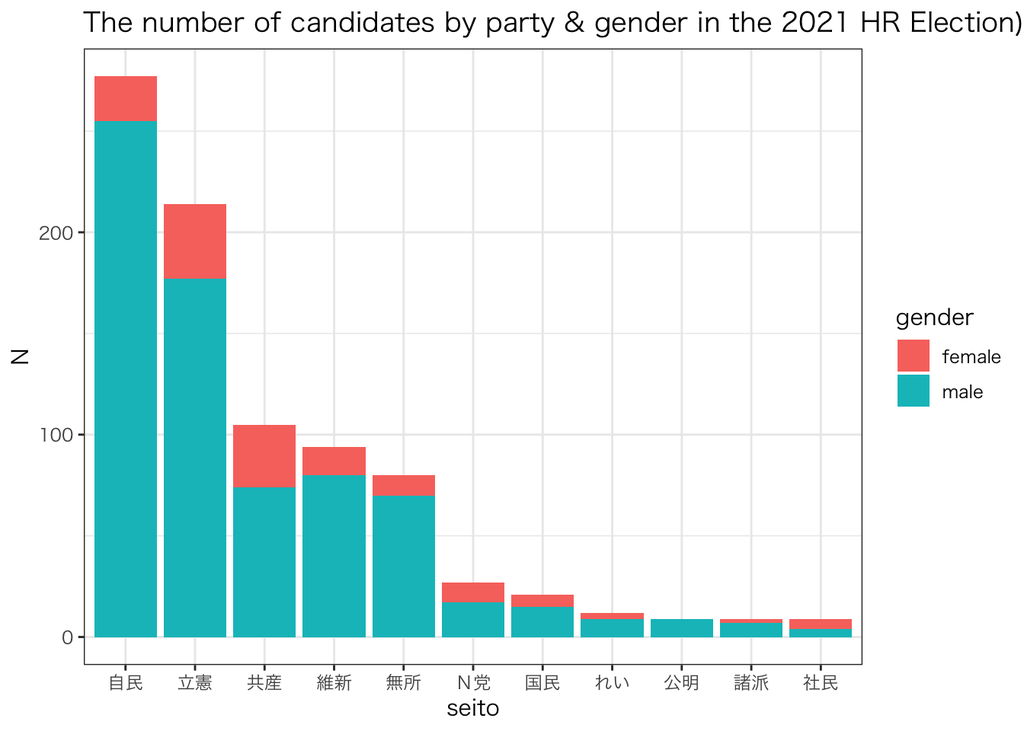

```r
res_1 %>%
  ggplot() +
  geom_bar(aes(x = seito,
               y = N,
               fill = gender),
           stat = "identity") +
  ggtitle("The number of candidates by party & gender in the 2021 HR Election)") +
  theme_bw(base_family = "HiraKakuProN-W3")
```

### 3.5.3 Dodge bars

##### `position = "dodge"`

- The bar chart above is not user friendly in terms of visualization
- Let’s dodge bars by adding `position = "dodge"` within `geom_bar()`
- Note: Assign `position = "dodge"` **OUT OF** `aes()`

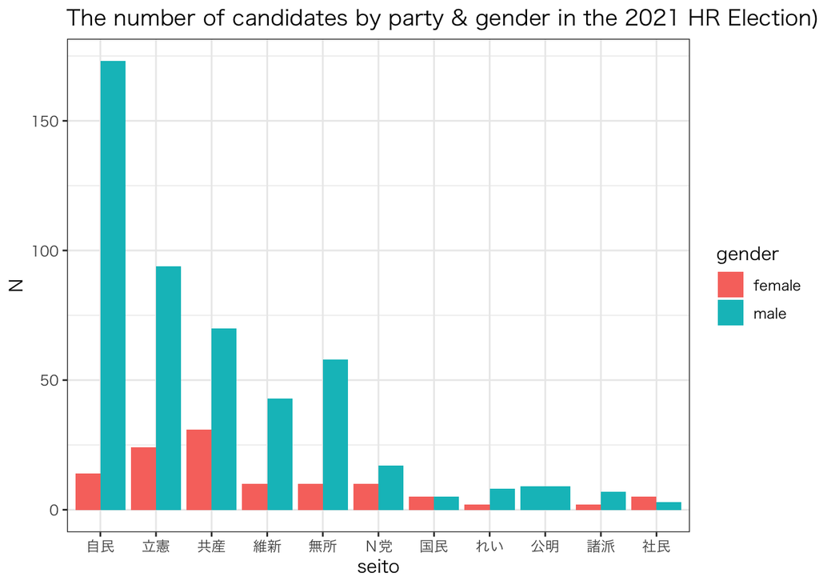

```r
res_1 %>%
  ggplot() +
  geom_bar(aes(x = seito,
               y = N,
               fill = gender),
           stat = "identity",
           position = "dodge") + # position = "dodge" is mapped out of aes()
  ggtitle("The number of candidates by party & gender in the 2021 HR Election)") +
  theme_bw(base_family = "HiraKakuProN-W3")
```

### 3.5.4 Customize the location of legend

##### `theme(legend.position = "bottom")`

- Let’s change the location of legend
- `theme()` enables us to precisely customize the outlook of a graph
- To change the location lf legend, you map `legend.position = "bottom"` within `theme()`  
  → The legend moves to the bottom
- The default is `"right"`
- You have thre other options: `"top", "left", and "none"`

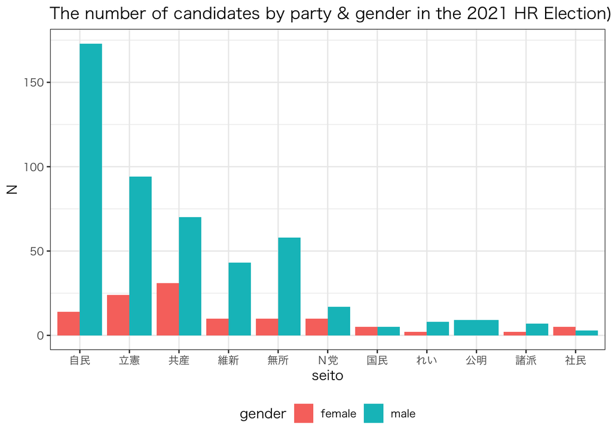

```r
res_1 %>%
  ggplot() +
  geom_bar(aes(x = seito,
y = N,
fill = gender),
 stat = "identity",
 position = "dodge") +
  ggtitle("The number of candidates by party & gender in the 2021 HR Election)") +
  theme_bw(base_family = "HiraKakuProN-W3") +
  theme(legend.position = "bottom")
```

## 3.6 `facet_wrap()`

- If you want to avoid using too many colors in a graph, you should use `facet_wrap()`
- You add `facet_wrap(~ variable name)`
- Suppose you want to draw a bar chart of the number of candidates (1) by party and (2) by gender

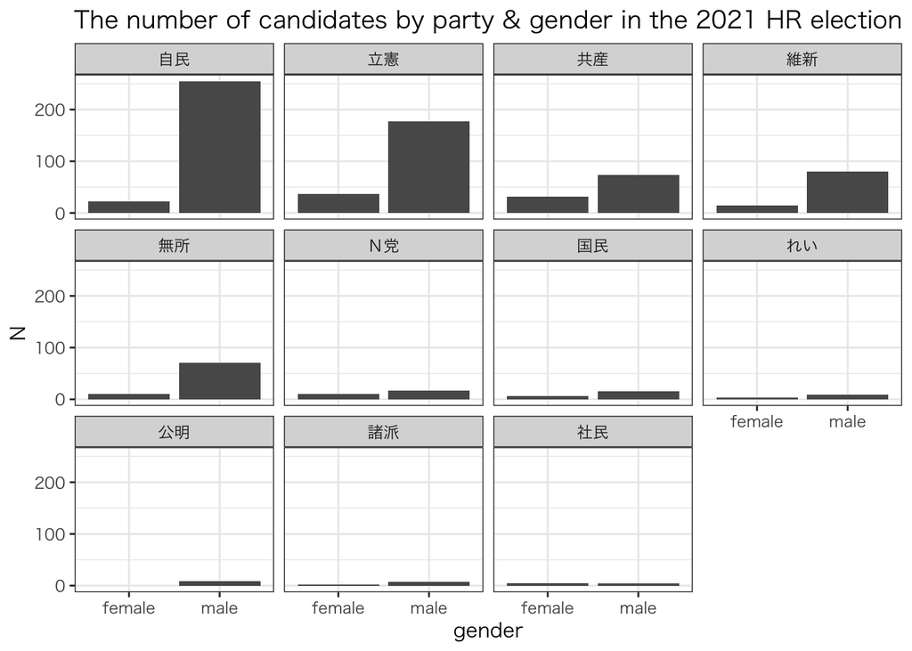

```r
res_1 %>%
  ggplot() +
  geom_bar(aes(x = gender,
y = N),
 stat = "identity") +
  ggtitle("The number of candidates by party & gender in the 2021 HR election") +
  theme_bw(base_family = "HiraKakuProN-W3") +
  facet_wrap(~ seito)
```

- You can replace `gender` with `seito` in mapping `aes()` and replace `seito` with `gender` in mapping `facet_wrap()` and draw the following bar chart.

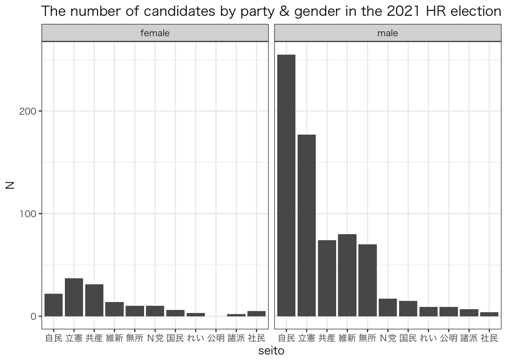

```r
res_1 %>%
  ggplot() +
  geom_bar(aes(x = seito,
y = N),
 stat = "identity") +
  ggtitle("The number of candidates by party & gender in the 2021 HR election") +
  theme_bw(base_family = "HiraKakuProN-W3") +
  facet_wrap(~ gender)
```

## 3.7 Customize the labels

##### `theme(axis.text.x = element_text(angle = XX, vjust = X, hjust = X)`

- Sometimes, the labels on `x-axis`are too long overlapping one another
- If this is the case, then you can rotate the labels on `x-axis` so that you can see them without overlapping one another
- You add `theme(axis.text.x= element_text()` as a new layer to get this done
- You can adjust an appropriate degrees of rotating the labels with `angle = ...`
- Here, I assign `angle = 30`

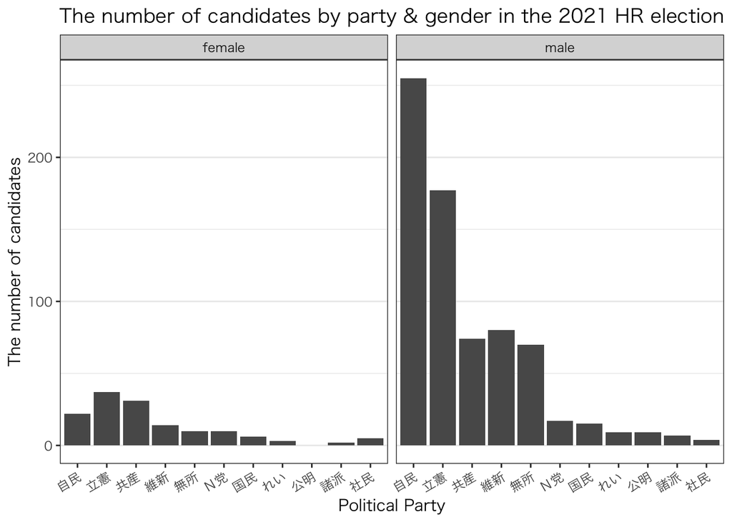

```r
res_1 %>%
  ggplot() +
  geom_bar(aes(x = seito,
y = N),
 stat = "identity") +
  facet_wrap(~ gender) +
  labs(x = "Political Party",
       y = "The number of candidates") +
  ggtitle("The number of candidates by party & gender in the 2021 HR election") +
  theme_minimal() +
  theme_bw(base_family = "HiraKakuProN-W3") +
  theme(axis.text.x= element_text(angle = 30, vjust = 1, hjust = 1),
panel.grid.major.x = element_blank())
```

## 3.8 Add a new layer to facet

- Map `fill = variable name` within `aes()`, then you can add a new layer
- First, make a variable `elec_result`, and then draw a bar chart with `ggplot()`

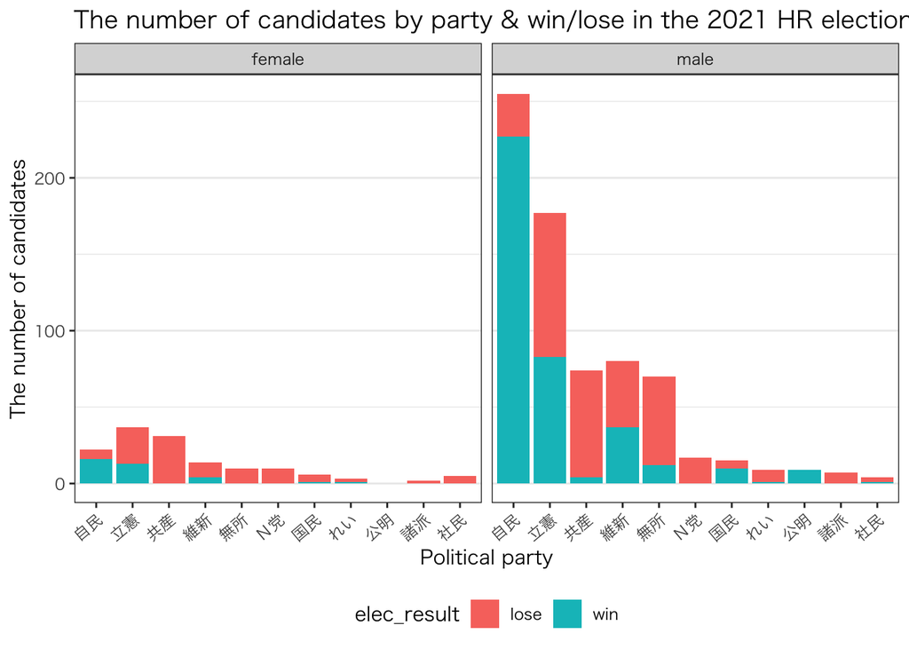

```r
res_1 %>%
  mutate(elec_result = if_else(wl == "0", "lose", "win")) %>%
  ggplot() +
  geom_bar(aes(x = seito,
               y = N,
               fill = elec_result),
           stat = "identity") +
  facet_wrap(~ gender) +
  labs(x = "Political party", y = "The number of candidates") +
  ggtitle("The number of candidates by party & win/lose in the 2021 HR election") +
  theme_minimal() +
  theme_bw(base_family = "HiraKakuProN-W3") +
  theme(axis.text.x = element_text(angle = 40,
                                   vjust = 1,
                                   hjust = 1),
        panel.grid.major.x = element_blank())  +
  theme(legend.position = "bottom")
```

## 3.9 How to swich `x-asis` and `y-axis`

- When the labels on `x-asix` is too long overlapping one another, you should simply swich `x-asis` and `y-axis`

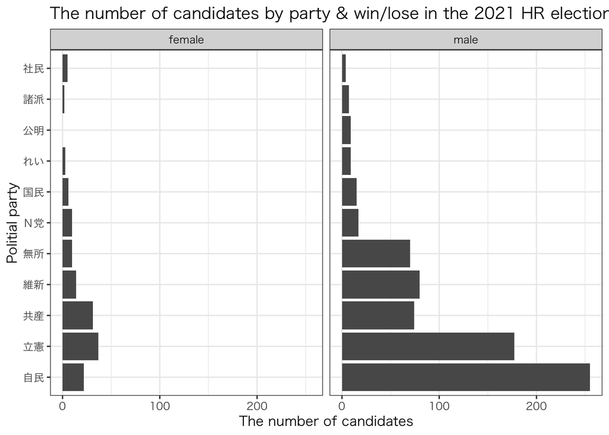

```r
res_1 %>%
  ggplot() +
  geom_bar(aes(x = N,
y = seito),
 stat = "identity") +
  facet_wrap(~ gender) +
  labs(x = "The number of candidates", y = "Politial party") + # ラベル修正
  ggtitle("The number of candidates by party & win/lose in the 2021 HR election") +
  theme_minimal() +
  theme_bw(base_family = "HiraKakuProN-W3")
```

#### Another way to swich `x-axis` and `y-axis`: `coord_flip()`

- You can swich `axes` by adding `coord_flip()`

```r
res_1 %>%
  ggplot() +
  geom_bar(aes(x = seito,
y = N),
 stat = "identity") +
  facet_wrap(~ gender) +
  labs(x = "The number of an", y = "政党") +
  theme_minimal() +
  theme_bw(base_family = "HiraKakuProN-W3") +
  coord_flip()
```

[output not shown]

# 4. Display numbers on bars

##### `geom_text(aes(label = variable name))`

## 4.1 A bar chart with numbers displayed

- Suppose you want to display numbers on the following bar chart

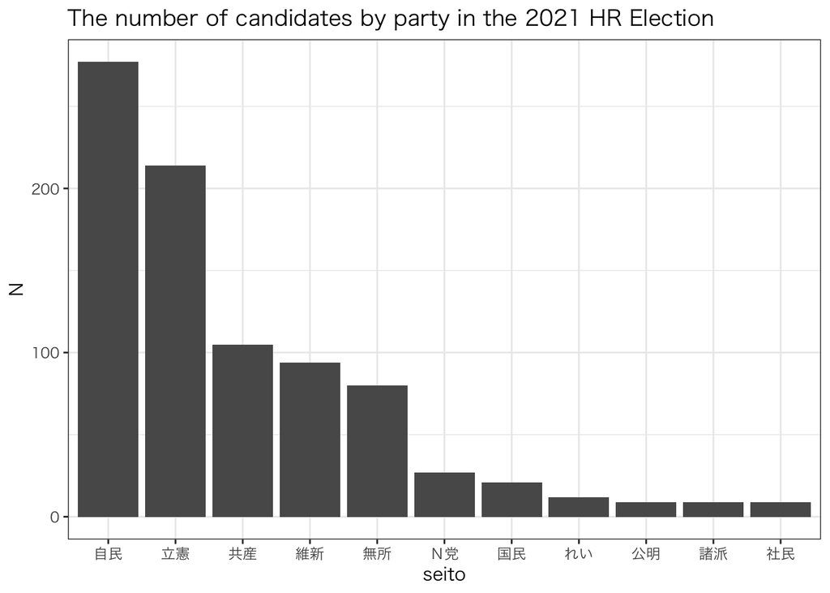

- The number of numbers (values) you want to displays on bars is 11
- The number of candidates these 11 parties nominated
- Check the data frame `res_1`

Check how you made `res_1`

```r
df <- read_csv("data/hr96-26.csv",
na = ".")
```

```r
df21 <- df %>%
  filter(year == 2021) %>% # Select the 2021 HR election data
  drop_na(seito) %>%　　　 # Drop missing values in seito
mutate(seito = factor(seito, # change the class of seito to factor and arrange in order you want
levels = c("自民",
 "立憲",
 "共産",
 "維新",
 "無所",
 "Ｎ党",
 "国民",
 "れい",
 "公明",
 "諸派",
 "社民")))
```

- Calculate the number of candidates by party, gender and win/lose and name it `res_1`

```r
res_1 <- df21 %>%
group_by(seito, gender, wl) %>%
summarise(N = n())
```

- Display `res_1`

```r
DT::datatable(res_1)
```

|  | seito | gender | wl | N |
| --- | --- | --- | --- | --- |
| 1 | 自民 | female | 0 | 6 |
| 2 | 自民 | female | 1 | 14 |
| 3 | 自民 | female | 2 | 2 |
| 4 | 自民 | male | 0 | 28 |
| 5 | 自民 | male | 1 | 173 |
| 6 | 自民 | male | 2 | 54 |
| 7 | 立憲 | female | 0 | 24 |
| 8 | 立憲 | female | 1 | 9 |
| 9 | 立憲 | female | 2 | 4 |
| 10 | 立憲 | male | 0 | 94 |

[output cut: 31 more lines]

- Using `res_1`, you calculate the number of candidates each party nominated (**= party_cand**) and name it `res_2`

```r
res_2 <- res_1 %>%
  group_by(seito) %>%
  summarize(party_cand = sum(N))
```

- Display `res_2`

```r
DT::datatable(res_2)
```

|  | seito | party_cand |
| --- | --- | --- |
| 1 | 自民 | 277 |
| 2 | 立憲 | 214 |
| 3 | 共産 | 105 |
| 4 | 維新 | 94 |
| 5 | 無所 | 80 |
| 6 | Ｎ党 | 27 |
| 7 | 国民 | 21 |
| 8 | れい | 12 |
| 9 | 公明 | 9 |
| 10 | 諸派 | 9 |

[output cut: 1 more lines]

- Adding `geom_text(aes(label = party_cand)`, you can display the numbers on bars

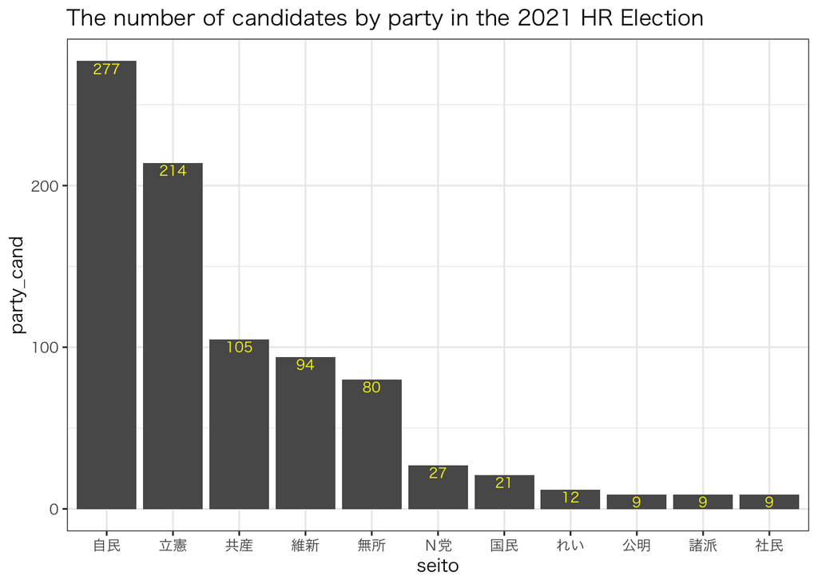

```r
res_2 %>%
  ggplot(aes(x = seito,
y = party_cand)) +
  geom_bar(aes(),
 stat = "identity",
 position = position_dodge(width = 0.9)) +
  geom_text(aes(label = party_cand),
  vjust = 1.2,
  colour = "yellow",
  position = position_dodge(width = 0.9),
  size = 3) +
  ggtitle("The number of candidates by party in the 2021 HR Election") +
  theme_bw(base_family = "HiraKakuProN-W3") +
  theme(legend.position = "bottom")
```

## 4.2 A bar chart with numbers displayed (dodge)

- Suppose you want to display numbers on the following bar chart

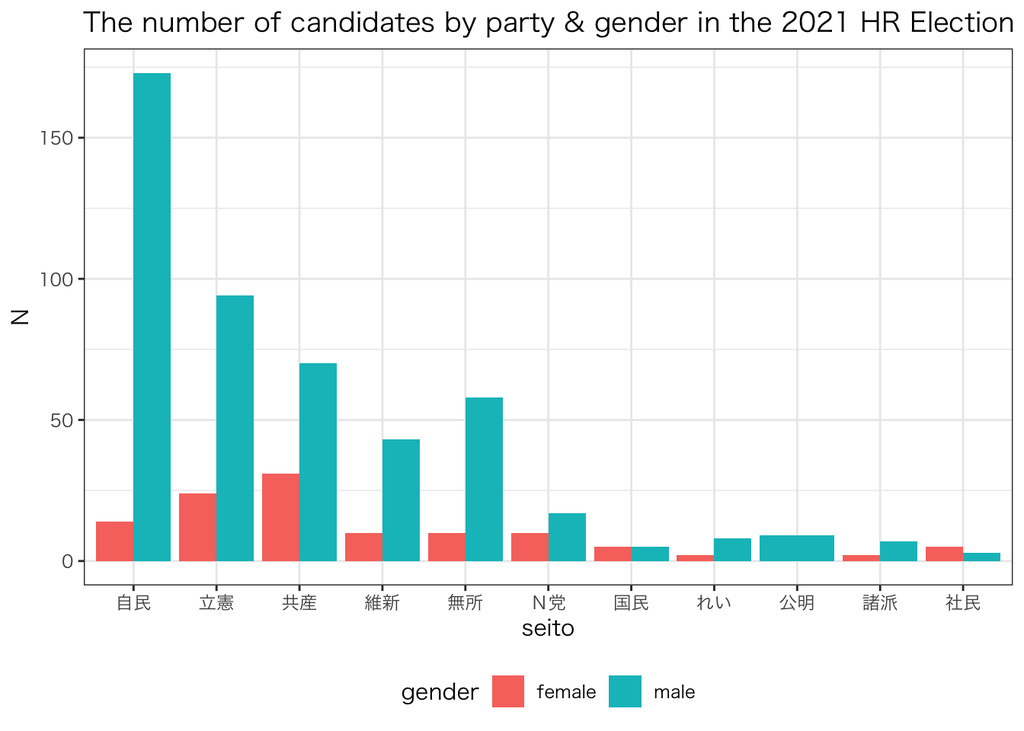

```r
DT::datatable(res_1)
```

|  | seito | gender | wl | N |
| --- | --- | --- | --- | --- |
| 1 | 自民 | female | 0 | 6 |
| 2 | 自民 | female | 1 | 14 |
| 3 | 自民 | female | 2 | 2 |
| 4 | 自民 | male | 0 | 28 |
| 5 | 自民 | male | 1 | 173 |
| 6 | 自民 | male | 2 | 54 |
| 7 | 立憲 | female | 0 | 24 |
| 8 | 立憲 | female | 1 | 9 |
| 9 | 立憲 | female | 2 | 4 |
| 10 | 立憲 | male | 0 | 94 |

[output cut: 31 more lines]

- Using `res_1`, you calculate the number of candidates 11 parties nominated by gender (**= total**) and name it `res_3`

```r
res_3 <- res_1 %>%
  group_by(seito, gender) %>%
  summarize(total = sum(N))
```

- Display `res_3`

```r
DT::datatable(res_3)
```

|  | seito | gender | total |
| --- | --- | --- | --- |
| 1 | 自民 | female | 22 |
| 2 | 自民 | male | 255 |
| 3 | 立憲 | female | 37 |
| 4 | 立憲 | male | 177 |
| 5 | 共産 | female | 31 |
| 6 | 共産 | male | 74 |
| 7 | 維新 | female | 14 |
| 8 | 維新 | male | 80 |
| 9 | 無所 | female | 10 |
| 10 | 無所 | male | 70 |

[output cut: 11 more lines]

- Adding `geom_text(aes(label = total)`, you can display the numbers on bars

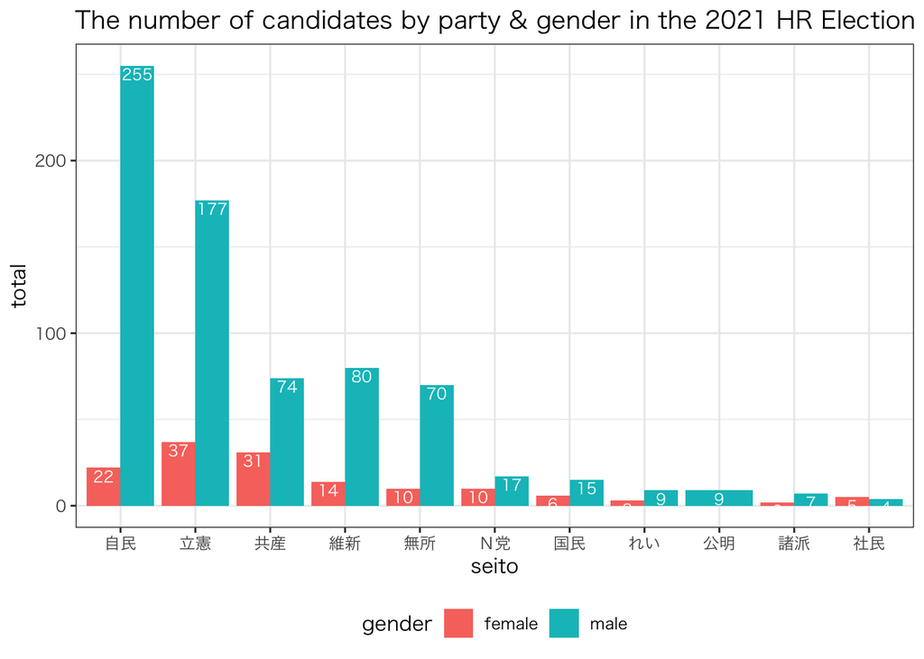

```r
res_3 %>%
  ggplot(aes(x = seito,
             y = total,
             fill = gender)) +
  geom_bar(aes(),
           stat = "identity",
           position = position_dodge(width = 0.9)) +
  geom_text(aes(label = total),
            vjust = 1.2,
            colour = "white",
            position = position_dodge(width = 0.9),
            size = 3) +
  ggtitle("The number of candidates by party & gender in the 2021 HR Election") +
  theme_bw(base_family = "HiraKakuProN-W3") +
  theme(legend.position = "bottom")
```

- The left side of the bar chart displays the numbers
- But, the right side of the bar chart fails to appropriately display the numbers
- You need to fix this
- Delete `vjust = 1.2`
- Change `colour = "white"` to `colour = "black"`

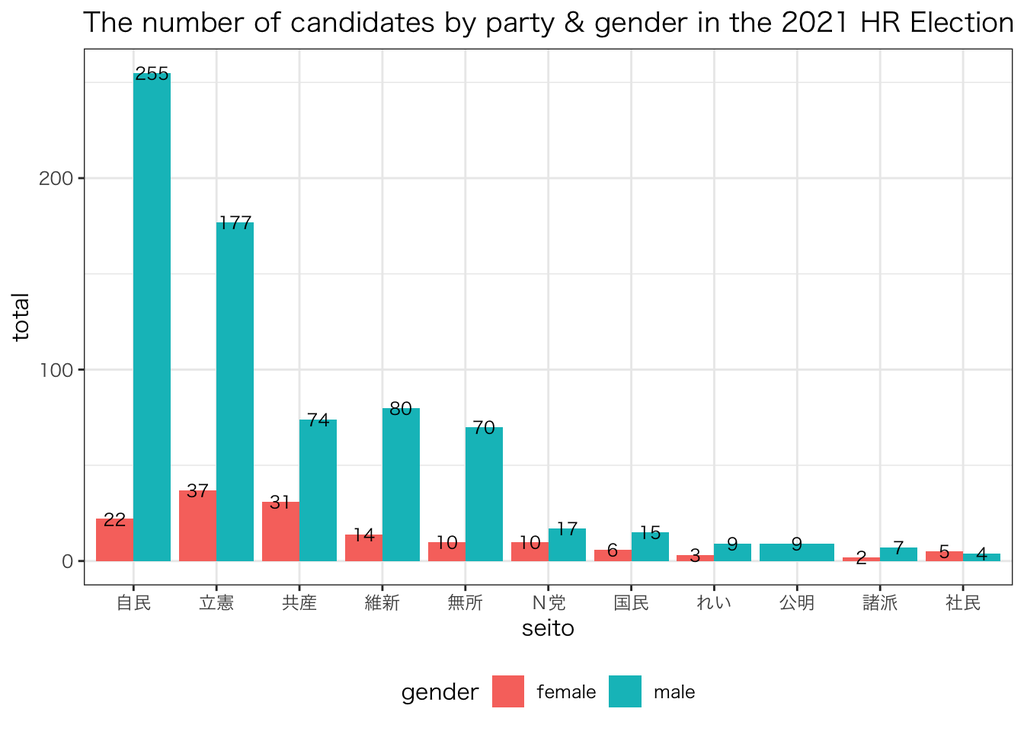

```r
res_3 %>%
  ggplot(aes(x = seito,
y = total,
fill = gender)) +
  geom_bar(aes(),
 stat = "identity",
 position = position_dodge(width = 0.9)) +
  geom_text(aes(label = total),
  colour = "black", # Change the color of the number
  position = position_dodge(width = 0.9),
  size = 3) +
   ggtitle("The number of candidates by party & gender in the 2021 HR Election") +
  theme_bw(base_family = "HiraKakuProN-W3") +
  theme(legend.position = "bottom")
```

## 4.3 A bar chart with numbers displayed (stacked)

#### `position = "stack"`

- Suppose you want to display numbers on the following bar chart

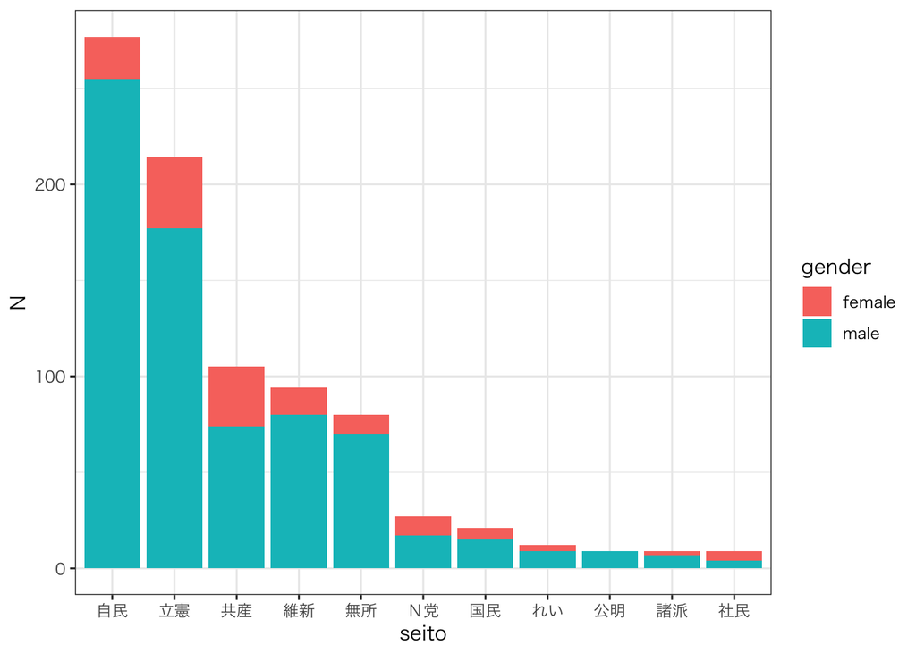

```r
res_4 <- res_1 %>%
  group_by(seito, gender) %>%
  summarize(total = sum(N))
```

- Display `res_4`

```r
DT::datatable(res_4)
```

|  | seito | gender | total |
| --- | --- | --- | --- |
| 1 | 自民 | female | 22 |
| 2 | 自民 | male | 255 |
| 3 | 立憲 | female | 37 |
| 4 | 立憲 | male | 177 |
| 5 | 共産 | female | 31 |
| 6 | 共産 | male | 74 |
| 7 | 維新 | female | 14 |
| 8 | 維新 | male | 80 |
| 9 | 無所 | female | 10 |
| 10 | 無所 | male | 70 |

[output cut: 11 more lines]

- Adding `geom_text(aes(label = total)`, you can display the numbers on bars

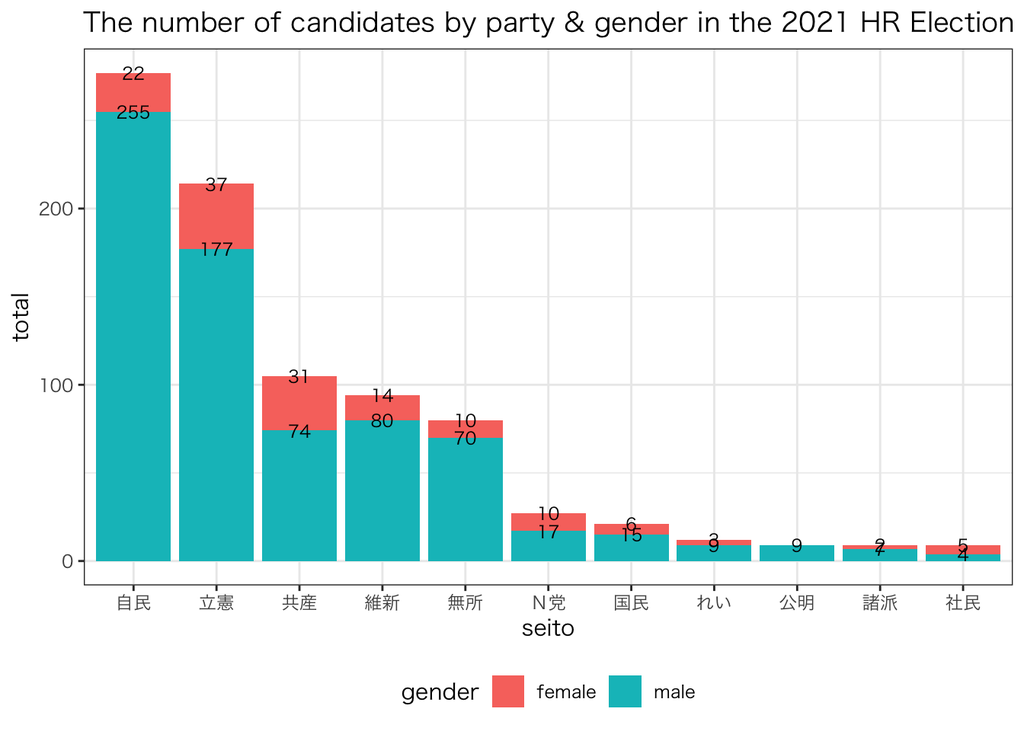

```r
res_4 %>%
  ggplot(aes(x = seito,
             y = total,
             fill = gender)) +
  geom_bar(aes(),
           stat = "identity",
           position = "stack") +  # Change to [position = "stack"]
  geom_text(aes(label = total),
            colour = "black",
            position = "stack", # Change to [position = "stack"]
            size = 3) +
  ggtitle("The number of candidates by party & gender in the 2021 HR Election") +
  theme_bw(base_family = "HiraKakuProN-W3") +
  theme(legend.position = "bottom")
```

# 5. How to save a graph

- You have two ways of saving a graph you made

| Type of format | Extension | File size | Quality |
| --- | --- | --- | --- |
| Vector | `.pdf (recommended) .svg` | large | Good |
| Bitmap | `.png (recommended) .bmp .jpg .jpeg` | small | OK |

- Let’s save the graph we made (`bar_plot_1`) with Vector and `png format`
- Using `ggsave()`, you save a graph made on `ggplot2`

##### Step 1:

- Name a graph you made, like `bar_plot1` (whatever name you like)
- Make a folder where you save your graphs, like `Figs` in you `RProject` folder

##### Step 2:

- Load {`ragg`}

```r
library(ragg)
```

```r
ggsave(filename = "Figs/plot1.png", # Assign where you want to save your graph and name it
  plot= bar_plot1,　 # The name of graph you made
  width= 6,　# Inch
  height= 3,　# Inch
  dpi = 400, 　# Assign graph resolution
  device= ragg::agg_png) # Avoid the garbled characters in a graph
```

- The name of the graph is `bar_plot1`
- You put a name on it and save it as `plot1.png`
- Make a folder where you save your graphs and name it as `Figs` in your `RProject` folder
- You can customize the size of the graph
- You can also cusomize the graph resolution, like 400
- `{ragg}` enables us to avoid the garbled characters in a graph

# 6. Exercise

- **Q6.1**:  
  In reference to `3.1 Draw a simple bar chart (1)`, draw a bar chart of the number of **male candidates** between the lower house elections between 1996 and 2021 in Japan.
- **Q6.2**:  
  In reference to `3.1 Draw a simple bar chart (1)`, draw a bar chart of the number of **female candidates** between the lower house elections between 1996 and 2021 in Japan.
- **Q6.3**:  
  In reference to `3.5.3 Dodge bars`, draw a bar chart of the number of candidates **dodged by gender** between the lower house elections between 1996 and 2021 in Japan.
- **Q6.4（Advance）**:  
  In reference to `3.8 Add a new layer to facet`, draw a bar chart of the number of winners (`wl = 1 & 2`) and losers (`wl = 0`) by party **faceted by candidate status (`status`)** in the 2021 HR election in Japan.  
  ・winners include both those who won in a single-member-district (`wl = 1`) and zombie winners (`wl = 2`)
- **Q6.5（Advance）**:  
  In reference to `4.2 A bar chart with numbers displayed (dodge)`, draw a bar chart of the number of single-member-district winners (`wl = 1`), zombie winners (`wl = 2`), and losers (`wl = 0`) by party **faceted by candidate status (`status`)** in the 2021 HR election in Japan.

**Reference**

[Tidy Animated Verbs](https://github.com/gadenbuie/tidyexplain?fbclid=IwAR3Zt0pQZa0IEvP-1gstatQ42VM5yJZvw2vUaFEqt_m2smUgtZpTqvuurLJ6z0)

[宋財泫 (Jaehyun Song)・矢内勇生 (statuki statanai)「私たちのR: ベストプラクティスの探究」](https://www.jaysong.net/RBook/)

[宋財泫「ミクロ政治データ分析実習（2022年度）」](https://www.jaysong.net/micro-book/)

[土井翔平（北海道大学公共政策大学院）「Rで計量政治学入門」](https://shohei-doi.github.io/quant_polisci/data-import.html)

[矢内勇生（高知工科大学）授業一覧](http://yukiyanai.github.io/teaching/)

浅野正彦, 矢内勇生.『Rによる計量政治学』オーム社、2018年

浅野正彦, 中村公亮.『初めてのRStudio』オーム社、2018年

Kieran Healy, DATA VISUALIZATION, Princeton, 2019

Kosuke Imai, Quantitative Social Science: An Introduction, Princeton University Press, 2017